# Tutorial for main functions in SurrogateRank package

In this tutorial, we will go through examples using the functions in the *SurrogateRank* package. First, install the package from CRAN and load it.

```r
#from Github
#library(devtools)
#install_github("laylaparast/SurrogateRank")
#from CRAN
#install.packages("SurrogateRank")
library(SurrogateRank)

# And some other useful packages
library(dplyr)
```

This package uses rank-based nonparametric approaches to evaluate surrogate markers in a small sample size setting. The first method, designed for the single-surrogate, single-trial setting, was introduced in:

Parast L, Cai T, & Tian L (2024). A rank-based approach to evaluate a surrogate marker in a small sample setting. Biometrics, 80(1), ujad035.

The methodology was later extended to high-dimensional settings in:

Hughes A, Parast L, Thiébaut R, & Hejblum BP (2025). RISE: Two-stage rank-based identification of high-dimensional surrogate markers applied to vaccinology. Statistics in Medicine, 44(20–22), e70241.

Finally, it was extended to the multi-trial setting in:

Hughes A, Thiébaut R, & Hejblum BP (2026). Meta-analysis of high-dimensional surrogate markers (manuscript submitted).

We describe each of these three methods below.

If you are viewing the html version of this tutorial, you can find the R markdown file here: https://github.com/laylaparast/SurrogateRank. It is the file called SurrogateRank_tutorial.Rmd.

# Single Surrogate: Evaluation and Power

Let’s first take a look at the example dataset (for one surrogate marker) included in the package, *example.data*. The dataset has 25 observations from a treatment group (group 1) and 25 observations from a control group (group 0), and contains *y1*, the primary outcome in the treatment group, *y0*, the primary outcome in the control group, *s1*, the surrogate marker in the treatment group, and *s0*, the surrogate marker in the control group.

```r
data(example.data)
names(example.data)
```

```
## [1] "y1" "y0" "s1" "s0"
```

Now, we calculate the metric $\delta$ which measures the strength of the surrogate using the function *delta.calculate*. This function requires the primary outcome and surrogate marker in each group, as shown below. The function returns the U-statistic for the treatment effect on the primary outcome, *u.y*, the U-statistic for the treatment effect on the surrogate marker, *u.s*, the difference between these, *delta.estimate*, and the standard error of each estimate, *sd.u.y, sd.u.s, sd.delta*. Lower values of *delta.estimate* indicate a stronger surrogate marker in the sense that the treatment effect on the surrogate is close to the treatment effect on the primary outcome.

```r
delta.calculate(yone = example.data$y1, yzero = example.data$y0, sone = example.data$s1, szero = example.data$s0)
```

```
## $u.y
## [1] 0.9376
##
## $u.s
## [1] 0.8192
##
## $delta.estimate
## [1] 0.1184
##
## $sd.u.y
## [1] 0.03307849
##
## $sd.u.s
## [1] 0.05974345
##
## $sd.delta
## [1] 0.03999733
```

Next, we formally test this *delta* using *test.surrogate*. The required arguments for this function are the same as *delta.calculate* In addition to the same returned quantities as *delta.calculate*, this function also returns the 1-sided confidence interval for *delta*, the epsilon that is used for the surrogacy test, and an indication of whether the provided surrogate is a valid surrogate based on this testing approach. For example, with this dataset, *is.surrogate* is *TRUE* meaning we can conclude this surrogate is valid.

```r
test.surrogate(yone = example.data$y1, yzero = example.data$y0, sone = example.data$s1, szero = example.data$s0)
```

```
## $u.y
## [1] 0.9376
##
## $u.s
## [1] 0.8192
##
## $delta.estimate
## [1] 0.1184
##
## $sd.u.y
## [1] 0.03307849
##
## $sd.u.s
## [1] 0.05974345
##
## $sd.delta
## [1] 0.03999733
##
## $ci.delta
## [1] -1.0000000  0.1841898
##
## $epsilon.used
## [1] 0.2327341
##
## $is.surrogate
## [1] TRUE
```

Optional arguments that *test.surrogate* takes are 1) *epsilon* which is the threshold to use for testing delta where the default calculates epsilon as a function of desired power for testing for a treatment effect using the surrogate, 2) *power.want.s* which is the desired power in (1), used to calculate *epsilon* if it is not provided; the default is 0.7, 3) *u.y.hyp* which is the hypothesized value of u.y used in the calculation of epsilon; the default is to use the estimated value *u.y*. For example, in the code below I specify the epsilon, making it more strict than what is used by default above.

```r
test.surrogate(yone = example.data$y1, yzero = example.data$y0, sone = example.data$s1, szero = example.data$s0, epsilon = 0.1)
```

```
## $u.y
## [1] 0.9376
##
## $u.s
## [1] 0.8192
##
## $delta.estimate
## [1] 0.1184
##
## $sd.u.y
## [1] 0.03307849
##
## $sd.u.s
## [1] 0.05974345
##
## $sd.delta
## [1] 0.03999733
##
## $ci.delta
## [1] -1.0000000  0.1841898
##
## $epsilon.used
## [1] 0.1
##
## $is.surrogate
## [1] FALSE
```

Next, the function *est.power* calculates the estimated power to detect a valid surrogate given a total sample size and specified alternative. This function would generally be used in a design stage before data are collected. The arguments are: 1) *n.total*, the total sample size in the study, 2) *rho*, the rank correlation between Y and S in group 0, default is 0.8, 3) *u.y.alt*, the specified alternative for *u.y*, 4) *delta.alt*, the specified alternative for *delta*, 5) *power.want.s*, the desired power for *u.s*, default is 0.7. The function returns the estimated power to detect a valid surrogate, given these specifications. For example, let’s say we are planning a study with a sample size of 50 and based on prior data or domain knowledge we specify the rank correlation between Y and S in group 0 to be 0.7, the alternative for *u.y* to be 0.9, and the specified alternative for *delta* to be 0.05, and our desired power for *u.s* is 0.6. Then, our estimated power is 0.84.

```r
est.power(n.total = 50, rho = 0.7, u.y.alt=0.9, delta.alt = 0.05, power.want.s=0.6)
```

```
## [1] 0.8421486
```

# High-Dimensional Surrogates - RISE

In this section, we illustrate the use of the high-dimensional surrogate methods implemented via the *Rank-based Identification of high-dimensional SurrogatE markers* (RISE) algorithm. We begin by examining the example dataset provided in the package.

```r
data(example.data.highdim)
names(example.data.highdim)
```

```
## [1] "y1"  "y0"  "s1"  "s0"  "hyp"
```

As in the previous example, this dataset contains 25 observations from a treatment group (group = 1) and 25 observations from a control group (group = 0). The variables `y1` and `y0` correspond to the primary response in the treated and control groups, respectively.

In contrast to the low-dimensional setting, `s1` and `s0` are matrices containing 1000 candidate surrogate markers for the treated and control groups. Each column represents a distinct candidate surrogate.

The final element, `hyp`, indicates whether each candidate surrogate is truly valid. A value of “null false” corresponds to a valid surrogate, whereas “null true” indicates an invalid surrogate. This information is only available because the dataset is simulated. In real applications, the validity of candidates is unknown.

To understand the ground truth, we inspect the indices of the true surrogate markers:

```r
which(example.data.highdim[["hyp"]] == "null false")
```

```
##   [1]   1   2   3   4   5   6   7   8   9  10  11  12  13  14  15  16  17  18
##  [19]  19  20  21  22  23  24  25  26  27  28  29  30  31  32  33  34  35  36
##  [37]  37  38  39  40  41  42  43  44  45  46  47  48  49  50  51  52  53  54
##  [55]  55  56  57  58  59  60  61  62  63  64  65  66  67  68  69  70  71  72
##  [73]  73  74  75  76  77  78  79  80  81  82  83  84  85  86  87  88  89  90
##  [91]  91  92  93  94  95  96  97  98  99 100
```

We observe that the first 100 markers are true positives, while the remaining 900 are negatives. This will serve as a reference when evaluating the performance of the method.

The RISE procedure consists of two stages, typically performed on separate (random) splits of the data to mitigate overfitting.

The first stage, known as *screening*, identifies promising candidate surrogates by applying a univariate test to each marker, followed by a multiple testing correction.

We now apply the screening step using the `rise.screen()` function on the full dataset (i.e., without sample splitting):

```r
screen.result <- rise.screen(
  yone = example.data.highdim$y1,
  yzero = example.data.highdim$y0,
  sone  = example.data.highdim$s1,
  szero = example.data.highdim$s0,
  power.want.s = 0.8
)
```

Let’s check the outputs of this function. The *screening.metrics* element returns a data frame with results from the testing of each marker one-by-one.

```r
screen.result[["screening.metrics"]] %>%
  head()
```

```
##    marker   epsilon  n   u.y    u.s   delta         sd      ci_lower
## 1 marker1 0.2369754 50 0.968 0.8784  0.0896 0.05448229 -1.539346e-05
## 2 marker2 0.2369754 50 0.968 0.9968 -0.0288 0.01987159 -6.148585e-02
## 3 marker3 0.2369754 50 0.968 0.9488  0.0192 0.03696773 -4.160651e-02
## 4 marker4 0.2369754 50 0.968 0.9312  0.0368 0.04058505 -2.995647e-02
## 5 marker5 0.2369754 50 0.968 0.9952 -0.0272 0.01965570 -5.953075e-02
## 6 marker6 0.2369754 50 0.968 0.6048  0.3632 0.08242459  2.276236e-01
##      ci_upper p_unadjusted   p_adjusted
## 1 0.179215393 3.415075e-03 4.435162e-02
## 2 0.003885853 5.565911e-26 1.113182e-23
## 3 0.080006511 1.919816e-09 3.428243e-08
## 4 0.103556474 4.064529e-07 6.663161e-06
## 5 0.005130755 6.845118e-27 1.711279e-24
## 6 0.498776389 9.371641e-01 1.000000e+00
```

The next element *significant.markers* gives the names of the markers which were judged significant at the provided $\alpha$ level (0.05 by default) after test multiplicity correction. Now, remember that markers 1 through 100 were true positives. Let’s check to see how many of our identified positives were true.

```r
screen.result[["significant.markers"]]
```

```
##  [1] "marker1"   "marker2"   "marker3"   "marker4"   "marker5"   "marker10"
##  [7] "marker11"  "marker12"  "marker13"  "marker15"  "marker16"  "marker17"
## [13] "marker18"  "marker19"  "marker20"  "marker21"  "marker22"  "marker23"
## [19] "marker25"  "marker26"  "marker27"  "marker28"  "marker29"  "marker30"
## [25] "marker32"  "marker35"  "marker36"  "marker37"  "marker38"  "marker39"
## [31] "marker40"  "marker41"  "marker42"  "marker43"  "marker44"  "marker45"
## [37] "marker46"  "marker47"  "marker50"  "marker51"  "marker52"  "marker53"
## [43] "marker54"  "marker55"  "marker60"  "marker61"  "marker62"  "marker63"
## [49] "marker65"  "marker66"  "marker67"  "marker68"  "marker69"  "marker70"
## [55] "marker71"  "marker72"  "marker73"  "marker75"  "marker77"  "marker78"
## [61] "marker79"  "marker80"  "marker82"  "marker85"  "marker86"  "marker87"
## [67] "marker88"  "marker89"  "marker90"  "marker91"  "marker92"  "marker93"
## [73] "marker94"  "marker95"  "marker96"  "marker97"  "marker100"
```

All of the claimed positives were truly positive, with no false positives. How many markers in total were determined significant?

```r
screen.result[["significant.markers"]] %>%
  length()
```

```
## [1] 77
```

The final element is a data frame giving the weights to pass to the evaluation stage to form a composite marker as a weighted, standardised sum of the markers screened as significant in the screening stage. We give a couple of different options for how to specify these weights. The default option, specified by setting *weight.mode = “inverse.delta”* in *rise.screen()*, sets the weights as the inverse of the estimated delta values. Let’s have a look at the weights given by the function

```r
screen.result[["screening.weights"]] %>%
  head()
```

```
##     marker     weight weight_unstandardised
## 1  marker1 0.01785714              11.16071
## 2  marker2 0.05555556              34.72222
## 3  marker3 0.08333333              52.08333
## 4  marker4 0.04347826              27.17391
## 5  marker5 0.05882353              36.76471
## 6 marker10 0.02857143              17.85714
```

Now let’s perform the evaluation stage using the *rise.evaluate()* function. For simplicity, let’s evaluate on the same data on which we screened. Although, in practice, you should probably perform sample splitting on the data to avoid overfitting. Note that we have to pass some elements from the screening stage into this function (the names of the significant markers and the weights).

```r
evaluate.results = rise.evaluate(
  yone = example.data.highdim$y1,
  yzero = example.data.highdim$y0,
  sone = example.data.highdim$s1,
  szero = example.data.highdim$s0,
  power.want.s = 0.8,
  markers = screen.result[["significant.markers"]],
  screening.weights = screen.result[["screening.weights"]]
)
```

Let’s look at the elements of this output. The first is *individual.metrics*, which is a re-application of the screening phase in the evaluation data on the specified markers only. Since, in this example, we used exactly the same data to screen and evaluate, this will give us the same results as before (with the adjusted p-values slightly different due to the reduced number of tests).

```r
evaluate.results[["individual.metrics"]] %>%
  head()
```

```
##     marker   epsilon  n   u.y    u.s   delta         sd      ci_lower
## 1  marker1 0.2369754 50 0.968 0.8784  0.0896 0.05448229 -1.539346e-05
## 2  marker2 0.2369754 50 0.968 0.9968 -0.0288 0.01987159 -6.148585e-02
## 3  marker3 0.2369754 50 0.968 0.9488  0.0192 0.03696773 -4.160651e-02
## 4  marker4 0.2369754 50 0.968 0.9312  0.0368 0.04058505 -2.995647e-02
## 5  marker5 0.2369754 50 0.968 0.9952 -0.0272 0.01965570 -5.953075e-02
## 6 marker10 0.2369754 50 0.968 0.9120  0.0560 0.04412105 -1.657266e-02
##      ci_upper p_unadjusted   p_adjusted
## 1 0.179215393 3.415075e-03 3.415075e-03
## 2 0.003885853 5.565911e-26 8.571504e-25
## 3 0.080006511 1.919816e-09 2.639747e-09
## 4 0.103556474 4.064529e-07 5.130634e-07
## 5 0.005130755 6.845118e-27 1.317685e-25
## 6 0.128572662 2.049811e-05 2.321110e-05
```

The second element, *gamma.s* gives us the values of the composite marker $\gamma$ for the treated and untreated groups.

```r
evaluate.results[["gamma.s"]][["gamma.s.one"]] %>%
  head() # treated gamma
```

```
## [1] 6.072436 5.375614 6.659558 5.737559 4.646631 4.178194
```

```r
evaluate.results[["gamma.s"]][["gamma.s.zero"]] %>%
  head()# untreated gamma
```

```
## [1] -5.970884 -4.489439 -5.219595 -5.445685 -6.191982 -5.541512
```

We see that the values of the composite surrogate are large and positive in the treated group, and large and negative in the untreated group, suggesting good separation of treatment groups by this variable. We can see that more formally in the third element *gamma.s.evaluate*, which gives us the results of the testing of gamma as a univariate surrogate in the evaluation data.

```r
evaluate.results[["gamma.s.evaluate"]]
```

```
##         delta      ci_lower      ci_upper            sd       epsilon
## -3.200000e-02 -6.467702e-02  6.770228e-04  1.986622e-02  2.369754e-01
##  p_unadjusted
##  2.927946e-25
```

The small delta value and p-value provide us evidence that this composite marker is a strong trial-level surrogate in this data.

The final element, *gamma.s.plot*, gives us a plot of the rankings of the composite marker gamma.s against the response in the evaluation data.

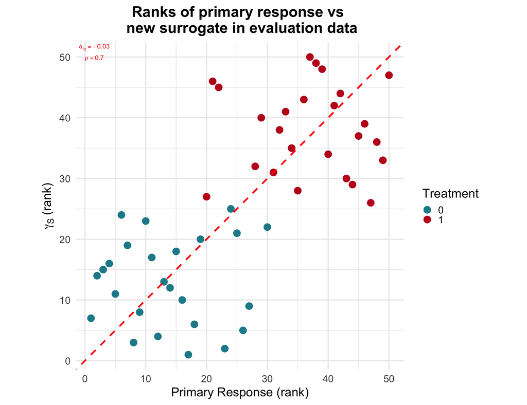

```r
evaluate.results[["gamma.s.plot"]]
```

If gamma is a strong trial-level surrogate, we expect separation of the treatment groups by gamma to be similar to that by the primary outcome. In this case, this is what we see, and this is made explicit by the annotation of the value of delta for the combined marker, which is close to 0. We may also have high spearman correlation between the *values* of the primary response and gamma (i.e. the points follow the diagonal line closely). A high level of correlation on the individual-level is a property of what is referred to in the literature as *individual-level surrogate markers*. While RISE is a method made for identifying *trial-level surrogate markers*, it is still interesting to see where trial- and individual-level properties may co-occur.

We can also apply both stages of RISE together with the function *test.surrogate.rise()*. This gives us two elements, *screening.results* and *evaluation.results* which are exactly the outputs of the individual screening and evaluation functions as explained above. Note that this function automatically performs random sample splitting on the data, by default at ratio screening:evaluation of 2:1. This ratio is controlled by the *screen.proportion* argument. If this is set to 1, the screening and evaluation are performed on the same dataset.

```r
test.surrogate.rise.result = test.surrogate.rise(
  yone = example.data.highdim$y1,
  yzero = example.data.highdim$y0,
  sone = example.data.highdim$s1,
  szero = example.data.highdim$s0,
  power.want.s = 0.8,
  screen.proportion = 2 / 3
)
```

```
## [1] "Screening step in progress."
## [1] "Evaluation step in progress."
```

Let’s check the results from this sample-split application of RISE. How many significant markers were identified?

```r
test.surrogate.rise.result[["screening.results"]][["significant.markers"]] %>%
  length()
```

```
## [1] 66
```

Now, what were the resulting metrics and plot in the 1/3 of the data left for evaluation?

```r
test.surrogate.rise.result[["evaluation.results"]][["gamma.s.evaluate"]]
```

```
##        delta     ci_lower     ci_upper           sd      epsilon p_unadjusted
##  -0.11111111  -0.24034302   0.01812079   0.07856742   0.00000000   0.92135040
```

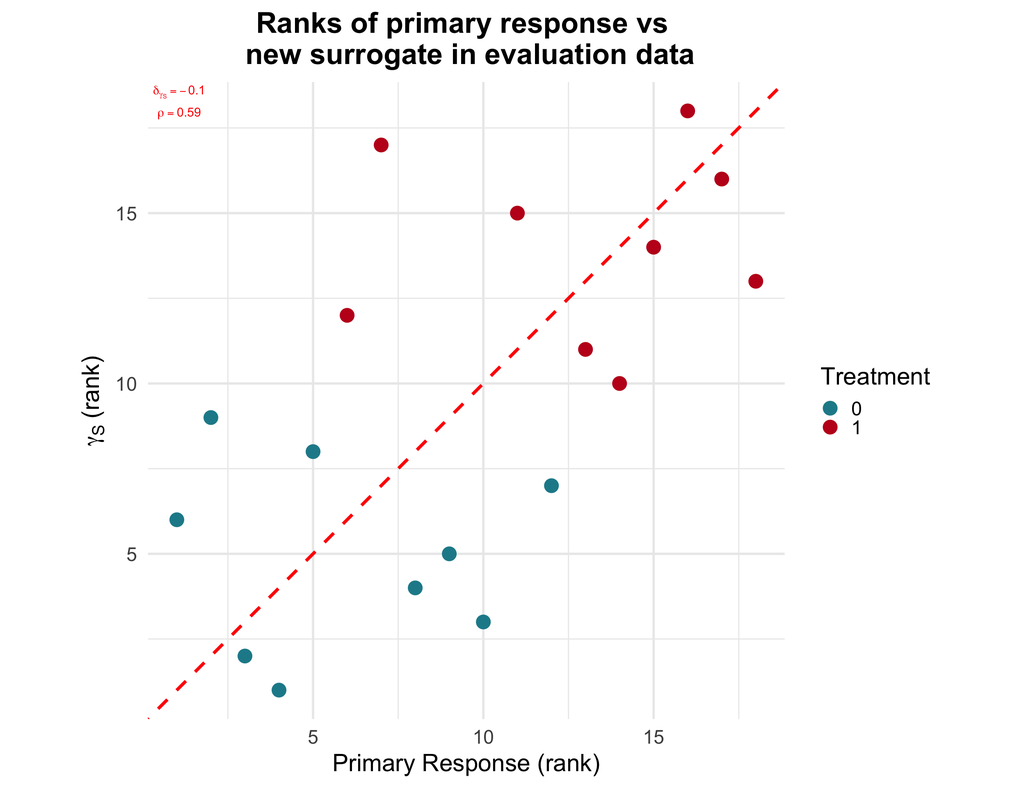

```r
test.surrogate.rise.result[["evaluation.results"]][["gamma.s.plot"]]
```

# Multi-Trial, High-Dimensional Surrogates - RISE-Meta

Finally, we will describe the extension of RISE to the multi-trial setting. This is applicable when we have access to data concerning the same treatment, candidate markers, and primary endpoint across multiple trials, and we would like to appropriately take into account between-study differences.

The main ideas of this method borrow from the two methods described above. Like RISE, RISE-Meta works in multiple stages:

- Apply RISE to the patient-level data within each study to derive point and standard error estimates for the surrogacy metric $\widehat{\delta}_{j,m}$ for each marker $j$ in trial $m$
- Pool these estimates across studies $m = 1, \dots, M$ using a parametric meta-analysis model, resulting in a pooled estimate $\widehat{\mu}_{j}$. Perform hypothesis tests on $\widehat{\mu}_{j}$ to obtain quantitative criteria for determining surrogate validity.
- Combine a subset of candidate markers into a weighted, standardised sum and re-evaluate its surrogacy, ideally on unseen data

Let’s start by loading and examining the example data for this setting.

```r
data(example.data.highdim.multistudy.ipd)
names(example.data.highdim.multistudy.ipd)
```

```
## [1] "y1"     "y0"     "s1"     "s0"     "study1" "study0" "hyp"
```

The form of this data is very similar to what we had in the previous section. We have *y1* and *y0* describing the values of the primary endpoint in the treated and control groups, matrices *s1* and *s0* whose columns are surrogate candidates, and *hyp* giving us the truth of the validity of the surrogates. However, we also have *study1* and *study0*, giving us the names of the studies corresponding to each sample. Let’s take a look at these:

```r
head(example.data.highdim.multistudy.ipd[["study1"]])
```

```
## [1] "study1" "study1" "study1" "study1" "study1" "study1"
```

```r
head(example.data.highdim.multistudy.ipd[["study0"]])
```

```
## [1] "study1" "study1" "study1" "study1" "study1" "study1"
```

```r
table(example.data.highdim.multistudy.ipd[["study1"]])
```

```
##
## study1 study2 study3 study4 study5
##     25     25     25     25     25
```

```r
table(example.data.highdim.multistudy.ipd[["study0"]])
```

```
##
## study1 study2 study3 study4 study5
##     25     25     25     25     25
```

For convenience, these are arranged such that all the participants from the same study are next to each other. There are five studies in total, each with 25 participants in each arm. In reality, study sizes will likely differ, where a larger sample size usually results in less uncertainty in estimating $\delta_{j,m}$. This uncertainty is taken into account in the meta-analysis model by giving more weight to more certain estimates when computing the pooled estimate $\mu_{j}$.

The main functions for RISE-Meta are *rise.screen.meta()* and *rise.evaluate.meta()*.

*rise.screen.meta()* applies RISE within each study and then combines the surrogacy estimates $\delta$ using meta-analysis. Let’s see how this works with our example data:

```r
rise.meta.screen.result <- rise.screen.meta(
  yone = example.data.highdim.multistudy.ipd$y1,
  yzero = example.data.highdim.multistudy.ipd$y0,
  sone = example.data.highdim.multistudy.ipd$s1,
  szero = example.data.highdim.multistudy.ipd$s0,
  studyone = example.data.highdim.multistudy.ipd$study1,
  studyzero = example.data.highdim.multistudy.ipd$study0,
  epsilon.study = 0.2,
  epsilon.meta = 0.2,
  meta.analysis.method = "RE",
  alternative = "two.sided",
  n.cores = 1
)
```

```
## Screening study 'study1'
```

```
## Screening study 'study2'
```

```
## Screening study 'study3'
```

```
## Screening study 'study4'
```

```
## Screening study 'study5'
```

```
## ℹ Adding new coordinate system, which will replace the existing one.
```

The main arguments of this function are the same as before, but we must also supply information on the studies corresponding to each sample. Let’s briefly discuss some of the other important arguments:

- *epsilon.study*: value of $\epsilon$ to be used for the within-study hypothesis testing
- *epsilon.meta*: value of $\epsilon$ to be used for the meta-analytic hypothesis testing
- *meta.analysis.method*: specification of the meta-analysis, which can be a random-effects (“RE”) or fixed-effect (“FE”) model
- *alternative*: the form of the alternative hypothesis to be used in testing. By default, this is “two.sided”, which uses a *two one-sided test* to test if $\mu_{j} \in (-\varepsilon, \varepsilon)$, which would indicate strong surrogacy.
- *n.cores*: number of cores to use in parallel computing (useful to speed things up when the data is large).

Now let’s examine some of the outputs.

```r
names(rise.meta.screen.result)
```

```
## [1] "screening.metrics.study"  "screening.metrics.meta"
## [3] "significant.markers"      "screening.weights"
## [5] "evaluation.metrics.study" "evaluation.metrics.meta"
## [7] "gamma.s.plot"
```

*screening.metrics.study* gives the within-study results. Effectively, this gives the results from the RISE method applied to each study like above, before considering pooling effects across studies. For example, let’s check the first marker evaluated in the first study

```r
rise.meta.screen.result[["screening.metrics.study"]] %>%
  filter(marker == "marker1", study == "study1")
```

```
##    study epsilon  marker  n    u.y    u.s  delta         sd p_unadjusted
## 1 study1     0.2 marker1 50 0.9904 0.9792 0.0112 0.01819011 1.540641e-25
##    p_adjusted
## 1 5.13547e-24
```

Here, we see that marker1 has a small $\delta$ value and is highly significant within this study.

*screening.metrics.meta* gives the results of the meta-analysis for each marker across studies. Again, let’s check a subset of columns for the first marker in the data

```r
rise.meta.screen.result[["screening.metrics.meta"]] %>%
  filter(marker == "marker1") %>%
  print(width = Inf)
```

```
## # A tibble: 1 × 15
##   marker  n.studies mu.delta se.delta ci.delta.lower ci.delta.upper
##   <chr>       <int>    <dbl>    <dbl>          <dbl>          <dbl>
## 1 marker1         5   0.0206   0.0117       -0.00440         0.0457
##   pi.delta.lower pi.delta.upper     tau2     Q    I2   ccc p.unadjusted
##            <dbl>          <dbl>    <dbl> <dbl> <dbl> <dbl>        <dbl>
## 1        -0.0120         0.0532 5.02e-11  5.99  33.2 0.354    0.0000536
##   p.adjusted    weight
##        <dbl>     <dbl>
## 1    0.00107 0.0000827
```

The most important variables of this output are:

- *mu.delta*, *se.delta*: the pooled estimate $\widehat{\mu}_{j}$ and its standard error. In this example, it is close to 0, indicating strong surrogacy across studies.
- *ci.delta.lower*, *ci.delta.upper*: $(1-2\alpha)\times100\%$ confidence intervals for $\widehat{\mu}_{j}$ (when using the default *two one-sided test*, otherwise replace $2\alpha$ with $\alpha$).
- *pi.delta.lower*, *pi.delta.upper*: $(1-\alpha)\times100\%$ prediction intervals representing the range of likely values for $\delta_{j,M+1}$ in a new, similar trial $M+1$
- *tau2*: estimate of $\tau^{2}$, the between-study heterogeneity parameter when using a random-effects model.
- *I2*: estimate of the $I^{2}$ statistic, which estimates the percentage of total variability attributable to between study differences. Here, it is estimated around $\frac{1}{3}$, meaning most of the variability is in the within-study estimates.
- *ccc*: concordance correlation coefficient between the study level effects $\boldsymbol{\widehat{U}_{Y}} = (\widehat{U}_{Y,1},\dots,\widehat{U}_{Y,M})^{T}$ and $\boldsymbol{\widehat{U}_{S}} = (\widehat{U}_{S,1},\dots,\widehat{U}_{S,M})^{T}$, which is close to 1 if these are highly concordant. Here, this is estimated as 0.35, indicating low-to-moderate positive concordance.

-*p.unadjusted* and *p.adjusted*: unadjusted and adjusted p-values from the equivalence testing. Here, these are close to 0 indicating high evidence against the null, resulting in a conclusion of valid surrogacy.

*significant.markers* is a vector giving the significant markers after multiplicity corrections.

```r
rise.meta.screen.result[["significant.markers"]]
```

```
## [1] "marker1" "marker2" "marker3" "marker4" "marker5" "marker6" "marker7"
## [8] "marker8" "marker9"
```

Here, we identified 9 out of the 10 truly positive markers.

*screening.weights* is a dataframe giving the relative weights to be used in the next stage for each marker.

```r
rise.meta.screen.result[["screening.weights"]] %>%
  arrange(desc(weight)) %>%
  head()
```

```
## # A tibble: 6 × 2
##   marker  weight
##   <chr>    <dbl>
## 1 marker5  1
## 2 marker3  0.682
## 3 marker8  0.588
## 4 marker9  0.570
## 5 marker7  0.314
## 6 marker1  0.307
```

We see that marker 5 has the highest possible weight at 1 and the others are given lower relative weights.

Finally, we can access various visualisations of these results through the *gamma.s.plot* object.

Firstly, we can visualise the similarity between the significant markers identified within each study through the *similarity.plots* object. This has two sub-plots. The first is a classic venn diagram showing the similarity between the markers identified by each study.

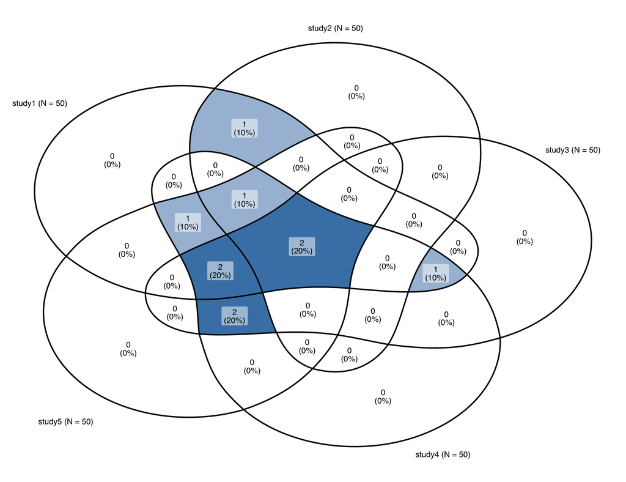

```r
rise.meta.screen.result[["gamma.s.plot"]]$similarity.plots$venn.plot
```

The second is an upset plot, which is a modification of the venn diagram which is useful when the number of studies becomes large.

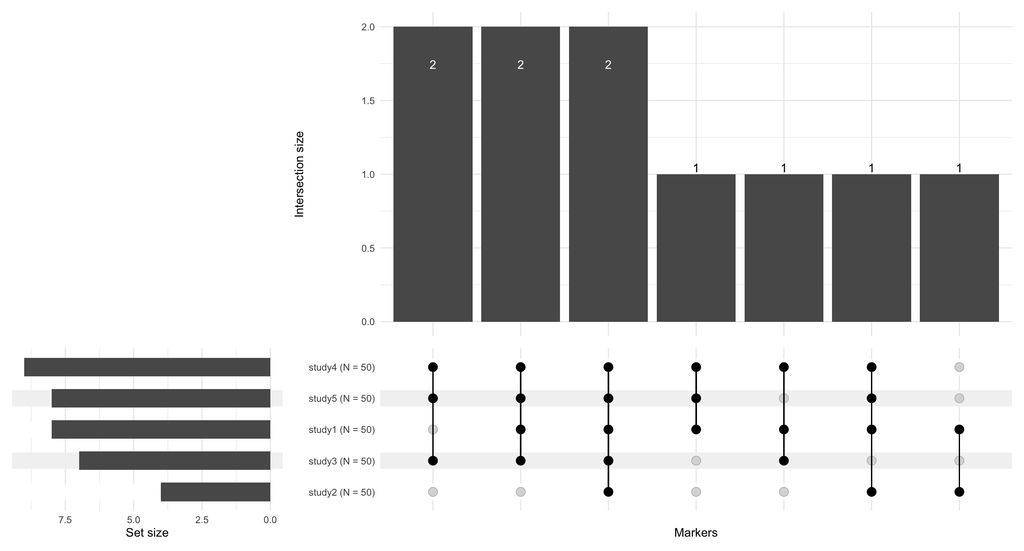

```r
rise.meta.screen.result[["gamma.s.plot"]]$similarity.plots$upset.plot
```

Here we see that the within-study analysis identify many common markers.

The main plot for the screening stage to visualise the results of the marker-level meta-analyses is the *screen.plot*

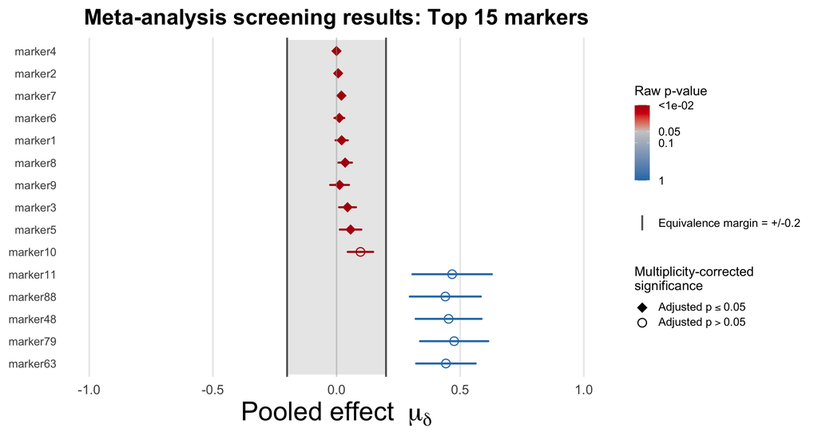

```r
rise.meta.screen.result[["gamma.s.plot"]][["screen.plot"]]
```

By default, this shows the top 15 markers by p-value, although this can be changed in *rise.screen.meta()* through the *screen.plot.topN* argument. For these top markers, it gives the pooled effect estimate $\widehat{\mu}_{j}$ for each one. The colour of the points corresponds to the raw p-values from the equivalence testing.

The other main function of RISE-Meta is *rise.evaluate.meta()*. The syntax and idea is very similar to the RISE method above: we input the data in the same form, specify the significant markers from the previous stage and their estimated weights, and evaluate their combination as a weighted sum called $\gamma$.

Again, for this example we’ll use the same data as we used in the screening stage for this evaluation, but ideally you should use independent or unseen data for this step.

```r
# significant markers from screening stage
markers = rise.meta.screen.result[["significant.markers"]]

# weights from screening stage
screening.weights = rise.meta.screen.result[["screening.weights"]]

# Run RISE-Meta evaluation
rise.meta.evaluate.result <- rise.evaluate.meta(
  yone = example.data.highdim.multistudy.ipd$y1,
  yzero = example.data.highdim.multistudy.ipd$y0,
  sone = example.data.highdim.multistudy.ipd$s1,
  szero = example.data.highdim.multistudy.ipd$s0,
  studyone = example.data.highdim.multistudy.ipd$study1,
  studyzero = example.data.highdim.multistudy.ipd$study0,
  epsilon.meta = 0.2,
  epsilon.study = 0.2,
  markers = markers,
  screening.weights = screening.weights
)
```

Let’s check out the main outputs of this function. Again, the element “evaluation.metrics.study” corresponds to the study-level evaluation of $\gamma$ whereas “evaluation.metrics.meta” is the meta-analytic evaluation across studies.

```r
rise.meta.evaluate.result[["evaluation.metrics.study"]]
```

```
##    study study.weight study.weight.relative epsilon marker  n    u.y u.s
## 1 study1   12986.1280             15.882262     0.2  gamma 50 0.9904   1
## 2 study2     915.1766              1.119277     0.2  gamma 50 0.9360   1
## 3 study3    6975.8399              8.531575     0.2  gamma 50 0.9840   1
## 4 study4   50423.7769             61.669163     0.2  gamma 50 0.9968   1
## 5 study5   10464.0550             12.797723     0.2  gamma 50 0.9888   1
##     delta    ci.lower     ci.upper          sd  p.unadjusted    p.adjusted
## 1 -0.0096 -0.02358803  0.004388027 0.008504117 2.509985e-111 6.274963e-111
## 2 -0.0640 -0.11825524 -0.009744758 0.032984845  1.868991e-05  1.868991e-05
## 3 -0.0160 -0.03536927  0.003369272 0.011775681  2.443337e-55  3.054171e-55
## 4 -0.0032 -0.00960156  0.003201560 0.003891872  0.000000e+00  0.000000e+00
## 5 -0.0112 -0.02688055  0.004480554 0.009533100  1.356404e-87  2.260673e-87
```

The following columns give us some interesting information:

- *p.adjusted* shows that $\gamma$ is significant within each study individually
- *study.weight.relative* gives us the relative weighting for each study for the meta-analysis stage. We see that study4 has 61% of the weight, whereas study2 has 1.1%. This is due to the fact that the within-study standard error is much larger (by about 10 times) in study2 compared to study4.

Next, we can look at the meta-analysis results

```r
rise.meta.evaluate.result[["evaluation.metrics.meta"]] %>%
  print(width = Inf)
```

```
## # A tibble: 1 × 14
##   marker n.studies       tau2 mu.delta se.delta ci.delta.upper ci.delta.lower
##   <chr>      <int>      <dbl>    <dbl>    <dbl>          <dbl>          <dbl>
## 1 gamma          5 0.00000469 -0.00701  0.00373       0.000929        -0.0150
##   pi.lower pi.upper     p.lower     p.upper           p     Q    I2
##      <dbl>    <dbl>       <dbl>       <dbl>       <dbl> <dbl> <dbl>
## 1  -0.0190  0.00495 0.000000416 0.000000314 0.000000416  4.78  16.4
```

This dataframe has the same form and syntax as the screening stage meta-analysis results. In particular, we see that $\widehat{\mu_{\gamma}} = -0.00701$, which is close enough to 0 to conclude valid surrogacy relative to the equivalence bound $\varepsilon = 0.2$, resulting in a small p-value $p = 0.000000416$.

The “gamma.s” element gives us the values of the combined variable $\gamma$ computed in each study. For example, if we wanted the values of gamma in study1 in the treated and untreated groups we could access them by

```r
rise.meta.evaluate.result[["gamma.s"]][["study1"]][["gamma.s.one"]] %>%
  head()
```

```
## [1] 3.075251 2.639635 1.318277 3.492249 3.692021 3.241623
```

```r
rise.meta.evaluate.result[["gamma.s"]][["study1"]][["gamma.s.zero"]] %>%
  head()
```

```
## [1] -1.552385 -3.651033 -3.975953 -2.114312 -1.760013 -1.713067
```

Finally, the “gamma.s.plot” element gives visualisations for the evaluation stage. The first of these is a “fit plot”, which plots the within-study estimates $\boldsymbol{\widehat{U}_{S}} = (\widehat{U}_{S,1},\dots,\widehat{U}_{S,M})^{T}$ against $\boldsymbol{\widehat{U}_{Y}} = (\widehat{U}_{Y,1},\dots,\widehat{U}_{Y,M})^{T}$.

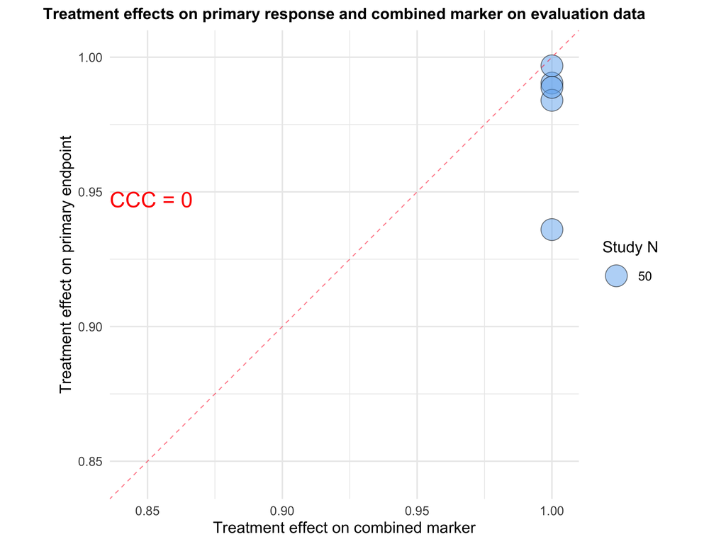

```r
rise.meta.evaluate.result[["gamma.s.plot"]][["fit.plot"]]
```

This plot can be used to evaluate the visual concordance between the trial-level effects and assess their heterogeneity between studies. Here, we see that, although our evidence suggests a strong trial-level surrogate marker, the treatment effects within each study are very similar (in particular, the treatment effects on $\gamma$ all take the max value of 1).

The argument for surrogacy of $\gamma$ would be a lot more convincing if, when the treatment effect on the primary endpoint varied, as did the treatment effect on $\gamma$. However, we cannot really evaluate this in these data, since the treatment effects on the primary endpoint are very homogeneous.

The next plot is a *forest plot*.

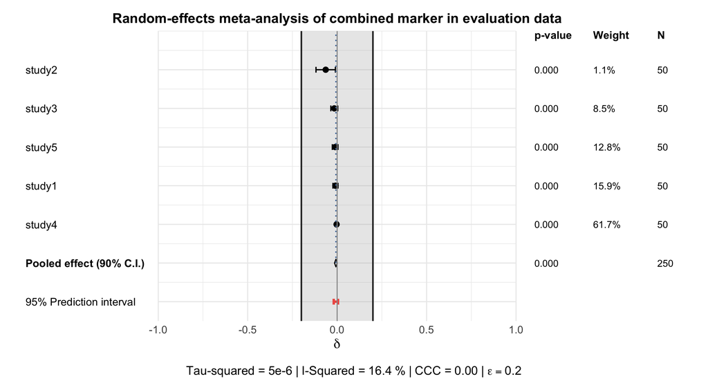

```r
rise.meta.evaluate.result[["gamma.s.plot"]][["forest.plot"]]
```

This shows each within-study estimate of $\delta$, followed by the pooled effect estimate, CIs, and PIs. The within-study p-values, weights, and sample sizes are given on the right. We can see that the within-study estimates and pooled estimate are close to 0, indicating strong surrogacy. The shaded region delimits the equivalence region $(-\varepsilon, \varepsilon)$.

Some qualitative evaluation metrics like the $I^{2}$, ccc as well as the equivalence bound $\varepsilon$ are provided at the bottom. This plot can be useful as an overall summary of the results of the meta-analytic evaluation.

That’s all for now!